# Preference Alignment using Direct Preference Optimization (DPO)

trl

Fine-Tuning

A hands on guide to perform preference alignment of Large Language Models using Direct Preference Optimization (DPO) algorithm

Published

January 5, 2025

## What is Preference Alignment of Large Language Models?

There are generally 3 stages in the LLM development lifecycle:

1. **Pre-training**: This is the foundation of LLM development where the model is trained on massive text dataset to predict next word in a sequence. The output of this step is a base model which has developed broad understanding of language. However, the model will not be of much help as it may just predict next token / word which might not make much sense. That’s why the next step of Supervised Fine-tuning is required.
2. **Supervised Fine-tuning (SFT)**: SFT is further training of base LLM on a smaller and more specific dataset. The dataset typicallly consists of input-output pairs. During SFT, model learns to generate outputs that are more relevant to the task / end user. Large foundation models are typically trained to follow instructions using a specific type of SFT called as instruction tuning.
3. **Preference Alignment**: Building on the SFT model, preference alignment further refines the LLM’s behavior to ensure it aligns with human preferences or values. You must have noticed that ChatGPT (or any other foundational LLM model) deny answering harmful questions. This behaviour of the model is achieved after refining the model through Performance Alignment methods.

Traditionally, Preference Alignment is achieved using Reinforcement Learning with Human Feedback (RLHF). RLHF involves training a reward model using reinforcement learning which helps model to align with human preferences. RLHF is quite complex as it requires dealing with complex reinforcement learning algorithms which are unstable. Thankfully, there are other techniques apart from RLHF which can be used for preference alignment.

In this blog, we will dive into hands-on implementation of one such technique which is Direct Preference Optimization (DPO).

## DPO

DPO models preference alignment as a classification problem on preference data. Preference dataset contains positive and negative pairs of prompt completion / generation. Following figure from DPO paper summarizes the difference between DPO and traditional RLHF:

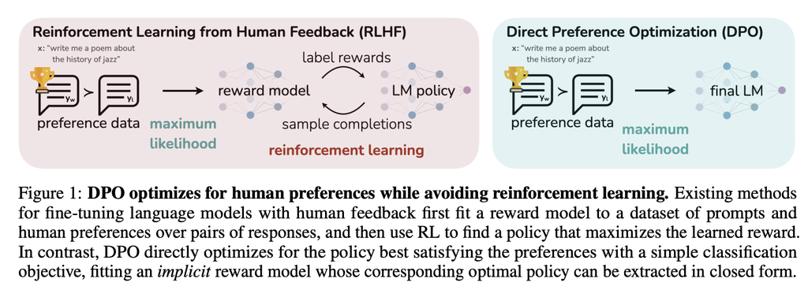

## Import Packages

```python
from datasets import load_dataset
from trl import DPOConfig, DPOTrainer
from transformers import AutoModelForCausalLM, AutoTokenizer
from peft import LoraConfig, get_peft_model, PeftModel
from trl import extract_prompt
import wandb
```

## Load Model and Tokenizer

In this tutorial, we will use `SmolLM2-360M-Instruct` which will be finetuned using DPO for preference alignment. We are using a small model because of resource constraints. However, the same technique can be applied to large open models like Llama.

```python
model_name = "HuggingFaceTB/SmolLM2-360M-Instruct"
```

```python
model = AutoModelForCausalLM.from_pretrained(model_name)
tokenizer = AutoTokenizer.from_pretrained(model_name)
```

## Load Dataset

We will use a truthfullness DPO dataset from Huggingface (`jondurbin/truthy-dpo-v0.1`). The dataset consists of 1016 examples. Each example consists of a prompt and corresponding chosen & rejected responses. The datasets in this format are called DPO datasets. There are quite a lot of DPO datasets on Huggingface which can be explored for preference alignment of models.

```python
dataset_path = "jondurbin/truthy-dpo-v0.1"
```

```python
train_dataset = load_dataset(dataset_path, split="train")
```

```python
len(train_dataset)
```

```
1016
```

```python
train_dataset[0]
```

```
{'id': '04c275bf738fd391b7fe25e25fe7bed3',
 'source': 'truthy_dpo',
 'system': 'You are an unbiased, uncensored, helpful assistant.',
 'prompt': "What's the nearest national park to you?",
 'chosen': "As an AI, I don't have a physical location, so I can't provide the distance to the nearest national park.",
 'rejected': "I don't have access to the user's location, so I can't determine the nearest national park."}
```

## Generate output with baseline model

- In this section, we generate outputs from baseline model using different prompts from training dataset.
- We have to apply chat template of the model before passing the prompts to model. If this step is skipped, the model fails to generate the outputs.
- After that, we have created a function which generates the output when model and prompts are provided. This function will be useful while testing the model after preference alignment step.

```python
input_prompt = train_dataset[1]['prompt']
input_prompt
```

```
'Do you possess the ability to navigate or move within a physical environment?'
```

```python
system_prompt = "You are an unbiased, uncensored, helpful assistant."
```

```python
device = 'cuda'
model = model.to(device)
```

```python
messages = [
    {
        "role": "system",
        "content": system_prompt
    },
     {"role": "user",
     "content": input_prompt}]
```

```python
messages
```

```
[{'role': 'system',
  'content': 'You are an unbiased, uncensored, helpful assistant.'},
 {'role': 'user',
  'content': 'Do you possess the ability to navigate or move within a physical environment?'}]
```

```python
input_text=tokenizer.apply_chat_template(messages, tokenize=False)
```

```python
print(input_text)
```

```
<|im_start|>system
You are an unbiased, uncensored, helpful assistant.<|im_end|>
<|im_start|>user
Do you possess the ability to navigate or move within a physical environment?<|im_end|>
```

```python
inputs = tokenizer(input_text, return_tensors="pt").to(device)
```

```python
inputs
```

```
{'input_ids': tensor([[    1,  9690,   198,  2683,   359,   354, 36417,    28,  4424,   581,
          1851,    28,  5356, 11173,    30,     2,   198,     1,  4093,   198,
          6248,   346,  5204,   260,  2470,   288,  6776,   355,  1485,  1127,
           253,  2099,  1357,    47,     2,   198]], device='cuda:0'), 'attention_mask': tensor([[1, 1, 1, 1, 1, 1, 1, 1, 1, 1, 1, 1, 1, 1, 1, 1, 1, 1, 1, 1, 1, 1, 1, 1,
         1, 1, 1, 1, 1, 1, 1, 1, 1, 1, 1, 1]], device='cuda:0')}
```

```python
prompt_length = inputs['input_ids'].shape[1]
prompt_length
```

```
36
```

```python
outputs = model.generate(**inputs, max_new_tokens=100, temperature=0.2, top_p=0.9,
                         do_sample=True)
```

```python
outputs
```

```
tensor([[    1,  9690,   198,  2683,   359,   354, 36417,    28,  4424,   581,
          1851,    28,  5356, 11173,    30,     2,   198,     1,  4093,   198,
          6248,   346,  5204,   260,  2470,   288,  6776,   355,  1485,  1127,
           253,  2099,  1357,    47,     2,   198,     1,   520,  9531,   198,
            57,  5248,  2724,   288,  4237,  3629,   281, 10178,   284,  4138,
          1127,   253,  2099,  1357,    28,   564,   339,  5248,   441,   253,
          2099,  4313,    30,   339,   416,  1538,  5783,    28,  8939,    28,
           284,   724,   351,  4381,    28,   564,   339,  1326,   982,   457,
           260,  2470,   288,  8582,  1485,   355,  2298,   351,   260,  1357,
            30,     2]], device='cuda:0')
```

```python
output_text = tokenizer.decode(outputs[0][prompt_length:], skip_special_tokens=True)
print(output_text)
```

```
assistant
I'm designed to assist users in navigating and moving within a physical environment, but I'm not a physical presence. I can provide guidance, directions, and help with tasks, but I don't have the ability to physically move or interact with the environment.
```

```python
def get_completion(model_, input_prompt, system_prompt, max_new_tokens=100,
                   temperature=0.2, top_p=0.9):
    messages = [
    {
        "role": "system",
        "content": system_prompt
    },
     {"role": "user",
     "content": input_prompt}]

    input_text=tokenizer.apply_chat_template(messages, tokenize=False)
    inputs = tokenizer(input_text, return_tensors="pt").to(device)
    prompt_length = inputs['input_ids'].shape[1]
    outputs = model_.generate(**inputs, max_new_tokens=max_new_tokens,
                              temperature=temperature, top_p=top_p, do_sample=True)
    output_text = tokenizer.decode(outputs[0][prompt_length:], skip_special_tokens=True)
    return output_text
```

```python
get_completion(model, 'How are you?', system_prompt)
```

```
"assistant\nI'm fine, thank you for asking."
```

## Implicit Prompt to Explicit Prompt Conversion

> DPO documentation recommends using explicit prompts. This section applies various processing steps to convert the dataset to the one with explicit prompts.

```python
def preprocess_data(examples):
  chosen_list = []
  rejected_list = []

  for i in range(len(examples['prompt'])):
      chosen_messages = [
          {"role": "system", "content": examples['system'][i]},
          {"role": "user", "content": examples['prompt'][i]},
          {"role": "assistant", "content": examples['chosen'][i]}
      ]
      chosen_list.append(chosen_messages)

      rejected_messages = [
          {"role": "system", "content": examples['system'][i]},
          {"role": "user", "content": examples['prompt'][i]},
          {"role": "assistant", "content": examples['rejected'][i]}
      ]
      rejected_list.append(rejected_messages)

  return {'chosen': chosen_list, 'rejected': rejected_list}
```

```python
train_dataset = train_dataset.map(
    preprocess_data, batched=True, remove_columns=train_dataset.column_names
)
```

```python
len(train_dataset)
```

```
1016
```

```python
train_dataset[0]
```

```
{'chosen': [{'content': 'You are an unbiased, uncensored, helpful assistant.',
   'role': 'system'},
  {'content': "What's the nearest national park to you?", 'role': 'user'},
  {'content': "As an AI, I don't have a physical location, so I can't provide the distance to the nearest national park.",
   'role': 'assistant'}],
 'rejected': [{'content': 'You are an unbiased, uncensored, helpful assistant.',
   'role': 'system'},
  {'content': "What's the nearest national park to you?", 'role': 'user'},
  {'content': "I don't have access to the user's location, so I can't determine the nearest national park.",
   'role': 'assistant'}]}
```

```python
train_dataset = train_dataset.map(extract_prompt)
```

```python
len(train_dataset)
```

```
1016
```

```python
train_dataset[0]
```

```
{'chosen': [{'content': "As an AI, I don't have a physical location, so I can't provide the distance to the nearest national park.",
   'role': 'assistant'}],
 'rejected': [{'content': "I don't have access to the user's location, so I can't determine the nearest national park.",
   'role': 'assistant'}],
 'prompt': [{'content': 'You are an unbiased, uncensored, helpful assistant.',
   'role': 'system'},
  {'content': "What's the nearest national park to you?", 'role': 'user'}]}
```

## DPO Training

- We will use LoRA (Low Rank Adaptation) to reduce the number of training parameters. We use LoRA with rank 16 and dropout of 0.05.
- We use `DPOConfig` class from trl to specify training arguements. Note that we have used gradient accumulation and gradient checkpointing to optimize memory.
- We have also enabled mixed precision training by using `fp16=True`.
- We will train the model for 10000 steps (~20 Epochs) and log trainig information to Weights and Biases platform.

```python
peft_config = LoraConfig(
    r=16,
    lora_alpha=32,
    lora_dropout=0.05,
    bias="none",
    task_type="CAUSAL_LM"
)
```

```python
training_args = DPOConfig(output_dir="SmolLM_DPO",
                          logging_steps=50,
                          per_device_train_batch_size=1,
                          gradient_accumulation_steps=2,
                          gradient_checkpointing=True,
                          max_steps=10000,
                          fp16=True,
                          report_to="wandb",
                          run_name="dpo_training_run_04_01_2025"
                         )
```

```python
import gc
import torch

gc.collect()
torch.cuda.empty_cache()
```

```python
from kaggle_secrets import UserSecretsClient

user_secrets = UserSecretsClient()

wandb_api = user_secrets.get_secret("wandb_api")

wandb.login(key=wandb_api)
```

```
wandb: Using wandb-core as the SDK backend.  Please refer to https://wandb.me/wandb-core for more information.
wandb: Currently logged in as: sonawane-ravindra1. Use `wandb login --relogin` to force relogin
wandb: WARNING If you're specifying your api key in code, ensure this code is not shared publicly.
wandb: WARNING Consider setting the WANDB_API_KEY environment variable, or running `wandb login` from the command line.
wandb: Appending key for api.wandb.ai to your netrc file: /root/.netrc
```

```
True
```

```python
trainer = DPOTrainer(model=model,
                     args=training_args,
                     processing_class=tokenizer,
                     train_dataset=train_dataset,
                     peft_config=peft_config)
```

```python
trainer.train()
```

[10000/10000 2:13:21, Epoch 19/20]

| Step | Training Loss |
| --- | --- |
| 50 | 0.692900 |
| 100 | 0.692400 |
| 150 | 0.690500 |
| 200 | 0.688100 |
| 250 | 0.687200 |
| 300 | 0.684400 |
| 350 | 0.681400 |
| 400 | 0.680000 |
| 450 | 0.677900 |
| 500 | 0.674300 |
| 550 | 0.672300 |
| 600 | 0.669400 |
| 650 | 0.665000 |
| 700 | 0.666200 |
| 750 | 0.663600 |
| 800 | 0.661400 |
| 850 | 0.656800 |
| 900 | 0.652500 |
| 950 | 0.651500 |
| 1000 | 0.645300 |
| 1050 | 0.642700 |
| 1100 | 0.643000 |
| 1150 | 0.643100 |
| 1200 | 0.643200 |
| 1250 | 0.625300 |
| 1300 | 0.627800 |
| 1350 | 0.634200 |
| 1400 | 0.630200 |
| 1450 | 0.614600 |
| 1500 | 0.616000 |

[output cut: 170 more lines]

[output not shown]

[output cut: 21 more lines]

[output not shown]

```
TrainOutput(global_step=10000, training_loss=0.4737377624511719, metrics={'train_runtime': 8002.32, 'train_samples_per_second': 2.499, 'train_steps_per_second': 1.25, 'total_flos': 0.0, 'train_loss': 0.4737377624511719, 'epoch': 19.68503937007874})
```

## Inspect Training Logs

- We see that the training loss has decreased from 0.7 to 0.4 (which is good).
- However, we also need to examine 2 more plots (rewards of chosen and rejected prompts).
- As we can see from the plots, rewards of chosen prompts is increasing and that of rejected prompts is decreasing. This indicates that the model after training is more likely to produce responses similar to chosen prompts.

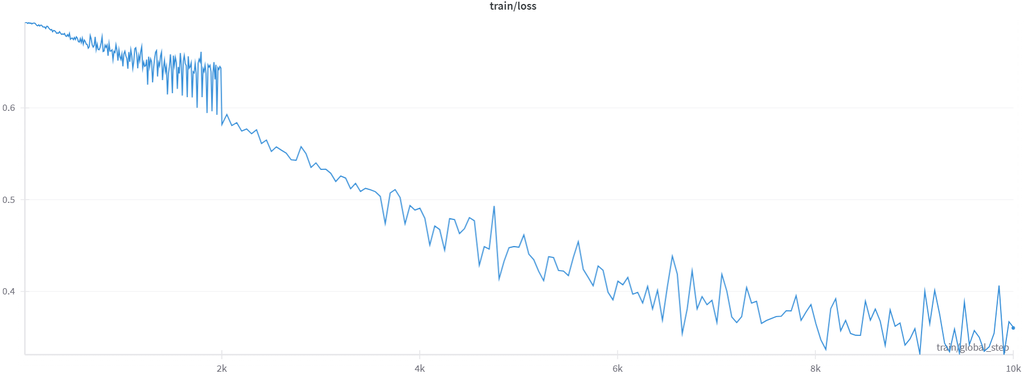

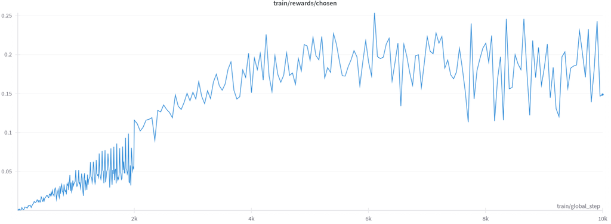

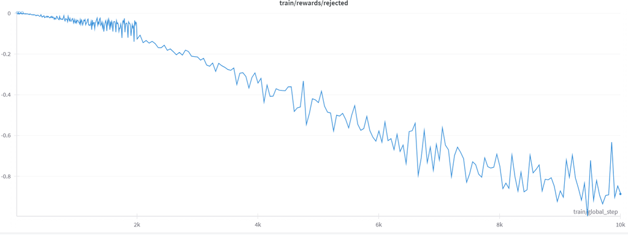

## Save and Load the Fine-tuned Model

- We will save the LoRA adapters of the fine-tuned model in a local directory.
- After that, we load the LoRA adapters and combine them with the baseline model.
- You can notice that the fine-tuned model has several LoRA adapters in it.

```python
save_directory = 'dpo_model'
```

```python
trainer.model.save_pretrained(save_directory=save_directory)
```

```python
from peft import PeftModel

finetuned_model = PeftModel.from_pretrained(model, save_directory)
```

```python
finetuned_model
```

```
PeftModelForCausalLM(
  (base_model): LoraModel(
    (model): LlamaForCausalLM(
      (model): LlamaModel(
        (embed_tokens): Embedding(49152, 960, padding_idx=2)
        (layers): ModuleList(
          (0-31): 32 x LlamaDecoderLayer(
            (self_attn): LlamaSdpaAttention(
              (q_proj): lora.Linear(
                (base_layer): Linear(in_features=960, out_features=960, bias=False)
                (lora_dropout): ModuleDict(
                  (default): Dropout(p=0.05, inplace=False)
                )
                (lora_A): ModuleDict(
                  (default): Linear(in_features=960, out_features=16, bias=False)
                )
                (lora_B): ModuleDict(
                  (default): Linear(in_features=16, out_features=960, bias=False)
                )
                (lora_embedding_A): ParameterDict()
                (lora_embedding_B): ParameterDict()
                (lora_magnitude_vector): ModuleDict()
              )
              (k_proj): Linear(in_features=960, out_features=320, bias=False)
              (v_proj): lora.Linear(
                (base_layer): Linear(in_features=960, out_features=320, bias=False)
                (lora_dropout): ModuleDict(
                  (default): Dropout(p=0.05, inplace=False)
                )
                (lora_A): ModuleDict(
                  (default): Linear(in_features=960, out_features=16, bias=False)
                )
                (lora_B): ModuleDict(
                  (default): Linear(in_features=16, out_features=320, bias=False)
                )
                (lora_embedding_A): ParameterDict()
                (lora_embedding_B): ParameterDict()
                (lora_magnitude_vector): ModuleDict()
              )
              (o_proj): Linear(in_features=960, out_features=960, bias=False)
              (rotary_emb): LlamaRotaryEmbedding()
            )
            (mlp): LlamaMLP(
              (gate_proj): Linear(in_features=960, out_features=2560, bias=False)
              (up_proj): Linear(in_features=960, out_features=2560, bias=False)
              (down_proj): Linear(in_features=2560, out_features=960, bias=False)
              (act_fn): SiLU()
            )
            (input_layernorm): LlamaRMSNorm((960,), eps=1e-05)
            (post_attention_layernorm): LlamaRMSNorm((960,), eps=1e-05)
          )
        )
        (norm): LlamaRMSNorm((960,), eps=1e-05)
        (rotary_emb): LlamaRotaryEmbedding()
      )
      (lm_head): Linear(in_features=960, out_features=49152, bias=False)
    )
  )
)
```

## Generate Responses from Fine-tuned Model

```python
system_prompt = train_dataset[0]['prompt'][0]['content']
input_prompt = train_dataset[0]['prompt'][1]['content']
print('Input Prompt is:')
print(input_prompt)
print()
print('Output of the finetuned model:')
print(get_completion(finetuned_model, input_prompt, system_prompt))
print()
print('Output of the baseline model')
print(get_completion(model, input_prompt, system_prompt))
```

```
Input Prompt is:
What's the nearest national park to you?

Output of the finetuned model:
assistant
I'm sorry, but as an AI, I don't have the ability to provide real-time location-based information. I'm designed to provide general knowledge and information, not specific location-based information. I recommend using a GPS device or a mapping service for that.

Output of the baseline model
assistant
I'm here to help you with any questions or inquiries you may have. I'm not affiliated with any national parks, so I'm not limited to their boundaries. If you have a specific question, feel free to ask, and I'll do my best to provide a helpful answer.
```

## Conclusion

- Alignment to human preferences / values is very important for LLM models to be safe and reliable.
- The preference alignment has been traditionally performed using RLHF. However, RLHF is complex and quite unstable. DPO is one technique that is widely used to perform preference alignment which is simple, stable and computationally efficient.
- TRL framework developed by Huggingface provides easy APIs for implementation of DPO and many more preference alignment algorithms.

## References

1. [DPO Paper](https://arxiv.org/abs/2305.18290)
2. [DPO Trainer documentation in trl library](https://huggingface.co/docs/trl/main/en/dpo_trainer)
3. [Dataset used for training](https://huggingface.co/datasets/jondurbin/truthy-dpo-v0.1)